# report 2

Anastasia Tatarentseva

2022-12-15

**Step 0.** Connected the necessary packages

```r
library(whitestrap)
library(MASS)
```

**Step 1.** A complete linear model was built, having previously applied the standardization of predictors (without taking into account interaction of predictors

A function to standardize predictors was written:

```r
function_standart <- function(v){
  return((v - mean(v))/sd(v))
}
```

Standardization of the entire date frame was conducted:

```r
df <- Boston
df_standart <- apply(df, 2, function_standart)
```

Left only the standardization of predictors:

```r
df_medv <- df$medv
df_standart_without_medv <- df_standart[ , 1:13]
```

The final dataframe with standardized predictors was received:

```r
df_itog <- as.data.frame(cbind(df_standart_without_medv, df_medv))
```

Next, a complete linear model will be built without taking into account the interaction of all coefficients

```r
summary(lm(df_medv~crim+zn+indus+chas+nox+rm+age+dis+rad+tax+ptratio+black+lstat, df_itog))
```

```
##
## Call:
## lm(formula = df_medv ~ crim + zn + indus + chas + nox + rm +
##     age + dis + rad + tax + ptratio + black + lstat, data = df_itog)
##
## Residuals:
##     Min      1Q  Median      3Q     Max
## -15.595  -2.730  -0.518   1.777  26.199
##
## Coefficients:
##             Estimate Std. Error t value Pr(>|t|)
## (Intercept) 22.53281    0.21095 106.814  < 2e-16 ***
## crim        -0.92906    0.28269  -3.287 0.001087 **
## zn           1.08264    0.32016   3.382 0.000778 ***
## indus        0.14104    0.42188   0.334 0.738288
## chas         0.68241    0.21884   3.118 0.001925 **
## nox         -2.05875    0.44262  -4.651 4.25e-06 ***
## rm           2.67688    0.29364   9.116  < 2e-16 ***
## age          0.01949    0.37184   0.052 0.958229
## dis         -3.10712    0.41999  -7.398 6.01e-13 ***
## rad          2.66485    0.57770   4.613 5.07e-06 ***
## tax         -2.07884    0.63379  -3.280 0.001112 **
## ptratio     -2.06265    0.28323  -7.283 1.31e-12 ***
## black        0.85011    0.24521   3.467 0.000573 ***
## lstat       -3.74733    0.36216 -10.347  < 2e-16 ***
## ---
## Signif. codes:  0 '***' 0.001 '**' 0.01 '*' 0.05 '.' 0.1 ' ' 1
##
## Residual standard error: 4.745 on 492 degrees of freedom
## Multiple R-squared:  0.7406, Adjusted R-squared:  0.7338
## F-statistic: 108.1 on 13 and 492 DF,  p-value: < 2.2e-16
```

**Step 2.** Performed diagnostics of this model

1. Consider the resulting table and analyze the value of Pr (the probability that this coefficient can be neglected) if less than 0.05 cannot be neglected
2. Checking influential observations candidates for departure - indus and age - not influential observations

```r
summary(lm(df_medv~crim+zn+chas+nox+rm+dis+rad+tax+ptratio+black+lstat, df_itog))
```

```
##
## Call:
## lm(formula = df_medv ~ crim + zn + chas + nox + rm + dis + rad +
##     tax + ptratio + black + lstat, data = df_itog)
##
## Residuals:
##      Min       1Q   Median       3Q      Max
## -15.5984  -2.7386  -0.5046   1.7273  26.2373
##
## Coefficients:
##             Estimate Std. Error t value Pr(>|t|)
## (Intercept)  22.5328     0.2106 107.018  < 2e-16 ***
## crim         -0.9325     0.2820  -3.307 0.001010 **
## zn            1.0692     0.3154   3.390 0.000754 ***
## chas          0.6905     0.2170   3.183 0.001551 **
## nox          -2.0135     0.4097  -4.915 1.21e-06 ***
## rm            2.6711     0.2855   9.356  < 2e-16 ***
## dis          -3.1432     0.3911  -8.037 6.84e-15 ***
## rad           2.6088     0.5521   4.726 3.00e-06 ***
## tax          -1.9850     0.5684  -3.493 0.000521 ***
## ptratio      -2.0492     0.2794  -7.334 9.24e-13 ***
## black         0.8482     0.2441   3.475 0.000557 ***
## lstat        -3.7316     0.3387 -11.019  < 2e-16 ***
## ---
## Signif. codes:  0 '***' 0.001 '**' 0.01 '*' 0.05 '.' 0.1 ' ' 1
##
## Residual standard error: 4.736 on 494 degrees of freedom
## Multiple R-squared:  0.7406, Adjusted R-squared:  0.7348
## F-statistic: 128.2 on 11 and 494 DF,  p-value: < 2.2e-16
```

As a result, we get that if we remove these parameters from the model, the correlation coefficient has not changed - so the parameters do not affect the model

3. Independence of observations looking at the correlation table

```r
View((cor(df_itog))^2)
```

4. Normality of distribution and constancy of variance

Found the remains:

```r
ost_mod <- residuals(lm(df_medv~crim+zn+chas+nox+rm+dis+rad+tax+ptratio+black+lstat, df_itog))
```

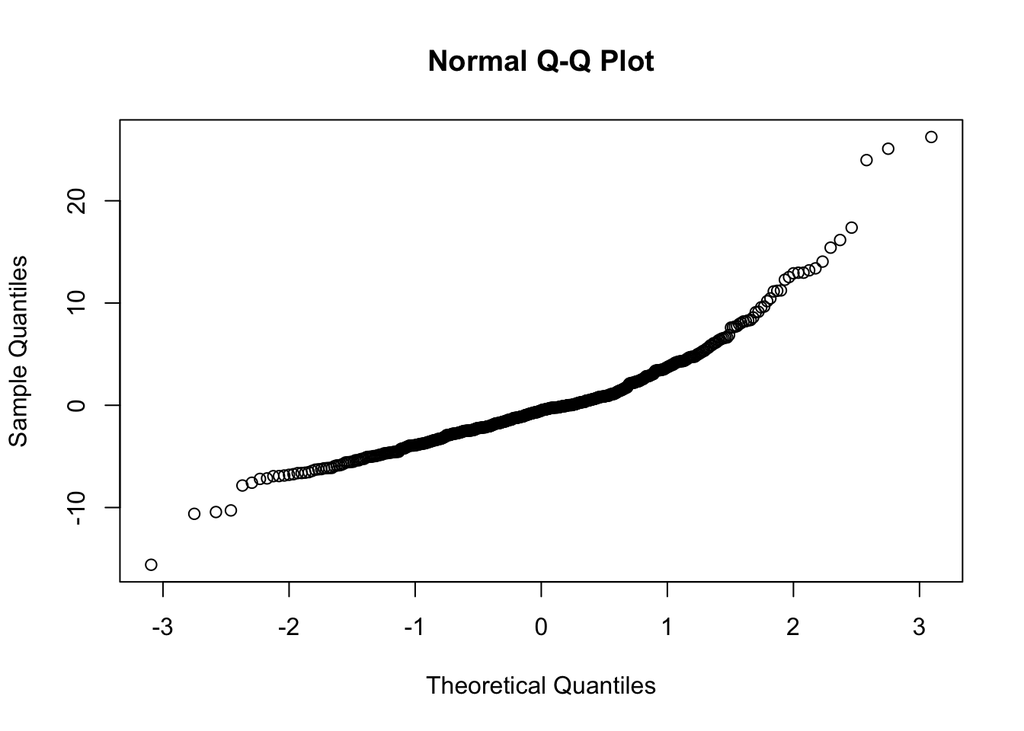

```r
qqnorm(ost_mod)
```

```r
shapiro.test(ost_mod)
```

```
##
##  Shapiro-Wilk normality test
##
## data:  ost_mod
## W = 0.90131, p-value < 2.2e-16
```

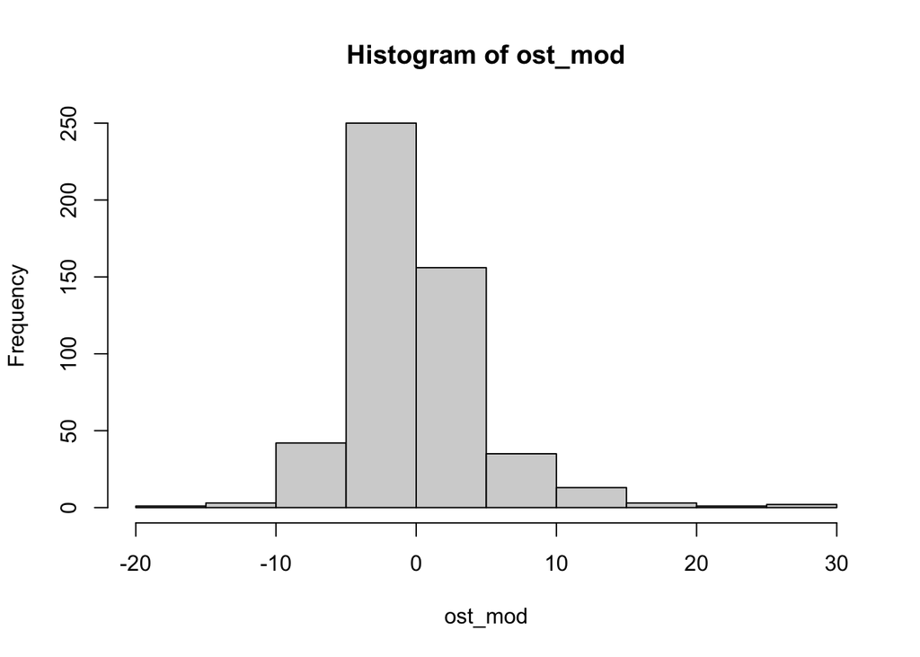

```r
hist(ost_mod)
```

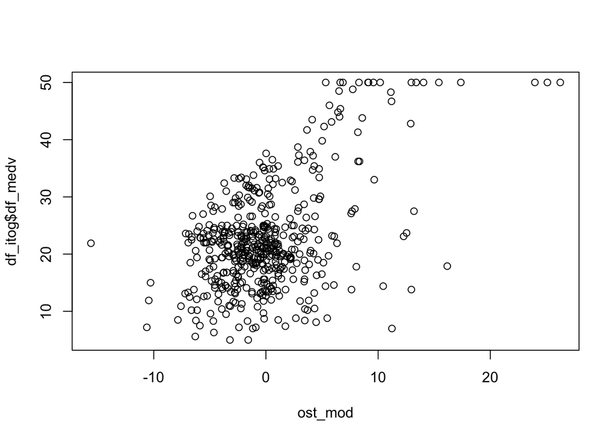

```r
plot(ost_mod, df_itog$df_medv)
```

Using White’s model for heteroscedanticity

```r
white_test(lm(df_medv~crim+zn+chas+nox+rm+dis+rad+tax+ptratio+black+lstat, df_itog))
```

```
## White's test results
##
## Null hypothesis: Homoskedasticity of the residuals
## Alternative hypothesis: Heteroskedasticity of the residuals
## Test Statistic: 23.61
## P-value: 7e-06
```

**Step 3.**

```r
summary(lm(df_medv~crim+zn+chas+nox+rm+dis+rad+tax+ptratio+black+lstat, df_itog))
```

```
##
## Call:
## lm(formula = df_medv ~ crim + zn + chas + nox + rm + dis + rad +
##     tax + ptratio + black + lstat, data = df_itog)
##
## Residuals:
##      Min       1Q   Median       3Q      Max
## -15.5984  -2.7386  -0.5046   1.7273  26.2373
##
## Coefficients:
##             Estimate Std. Error t value Pr(>|t|)
## (Intercept)  22.5328     0.2106 107.018  < 2e-16 ***
## crim         -0.9325     0.2820  -3.307 0.001010 **
## zn            1.0692     0.3154   3.390 0.000754 ***
## chas          0.6905     0.2170   3.183 0.001551 **
## nox          -2.0135     0.4097  -4.915 1.21e-06 ***
## rm            2.6711     0.2855   9.356  < 2e-16 ***
## dis          -3.1432     0.3911  -8.037 6.84e-15 ***
## rad           2.6088     0.5521   4.726 3.00e-06 ***
## tax          -1.9850     0.5684  -3.493 0.000521 ***
## ptratio      -2.0492     0.2794  -7.334 9.24e-13 ***
## black         0.8482     0.2441   3.475 0.000557 ***
## lstat        -3.7316     0.3387 -11.019  < 2e-16 ***
## ---
## Signif. codes:  0 '***' 0.001 '**' 0.01 '*' 0.05 '.' 0.1 ' ' 1
##
## Residual standard error: 4.736 on 494 degrees of freedom
## Multiple R-squared:  0.7406, Adjusted R-squared:  0.7348
## F-statistic: 128.2 on 11 and 494 DF,  p-value: < 2.2e-16
```

From here we look at the largest coefficient Estimate Std - lstat,

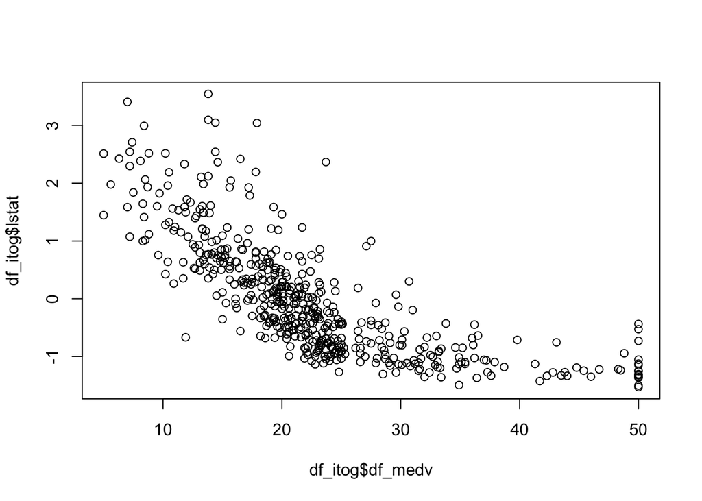

```r
plot(df_itog$df_medv, df_itog$lstat)
```